# Parcial 1

Hector Luis Blandón Espitia- Simulación y teoría de la desición

2022-03-24

## 1. La tabla mostrada contiene valores de población, en cientos de miles, de las diez ciudades más pobladas de cuatro países en el año 1967:

**Datos**

| **Argentina** | **EE.UU** | **Holanda** | **Japón** |
| --- | --- | --- | --- |
| 29.66 | 77.81 | 8.68 | 110.21 |
| 7.61 | 35.50 | 7.31 | 32.14 |
| 6.35 | 24.79 | 6.02 | 18.88 |
| 4.10 | 20.02 | 2.64 | 16.38 |
| 3.8 | 16.70 | 1.75 | 13.37 |
| 2.75 | 9.39 | 1.72 | 11.92 |
| 2.70 | 9.38 | 1.51 | 10.71 |
| 2.69 | 8.76 | 1.42 | 7.8 |
| 2.51 | 7.63 | 1.31 | 7.7 |
| 2.44 | 7.5 | 1.29 | 7 |

```r
bplot = boxplot(poblacion~paises, main = 'Población de ciudades por país en el año 1967', xlab = "Paises", ylab = "Población", col = "green",
        border = "red");
mediageneral = tapply(poblacion, paises, mean); mediageneral
```

```
## Argentina     EE.UU   Holanda     Japón
##     6.461    21.748     3.365    23.611
```

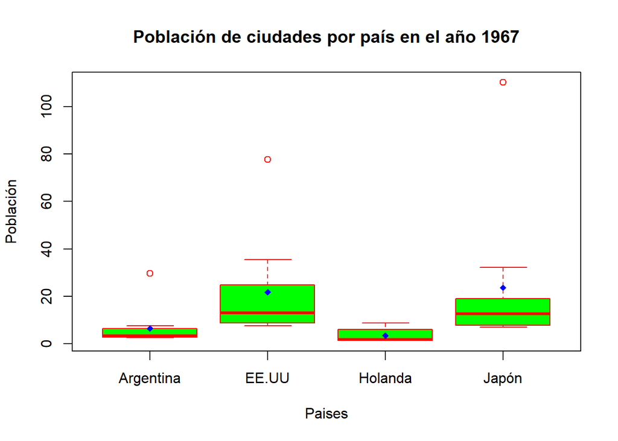

```r
xi <-  seq(bplot$n)
points(xi, mediageneral, col = 'blue', pch=18);
```

```r
desviacionEstandar = tapply(poblacion, paises, sd);
desviacionEstandar
```

```
## Argentina     EE.UU   Holanda     Japón
##  8.340645 21.721691  2.837328 31.329551
```

## 2. Avianca se encuentra estudiando la situación de venta de puesto en el vuelo Armenia – Bogotá puesto que ha identificado que el 2% de las personas que reservaron puesto, no se presentan a la hora del embarque. Teniendo en cuenta que el avión A320 utilizado en esta ruta tiene una capacidad para 180 pasajeros, la empresa decide vender 181 tiquetes. ¿Cuál es la probabilidad de que todas las personas que llegan a embarque puedan tener su silla asegurada y no se presenten quejas por “sobre-vender” sillas ante la aeronáutica civil? Asuma que las llegadas de los pasajeros siguen una distribución Poisson.

```r
#x = numero de pasajeros / vuelo
#p(x<=180)
#2% no se presentan -> 3.6 personas (promedio de personas que no se presenta al vuelvo)
#98% se presentan -> 176.4 personas
1 - sum(dpois (0:180, 176.4))
```

```
## [1] 0.3744755
```

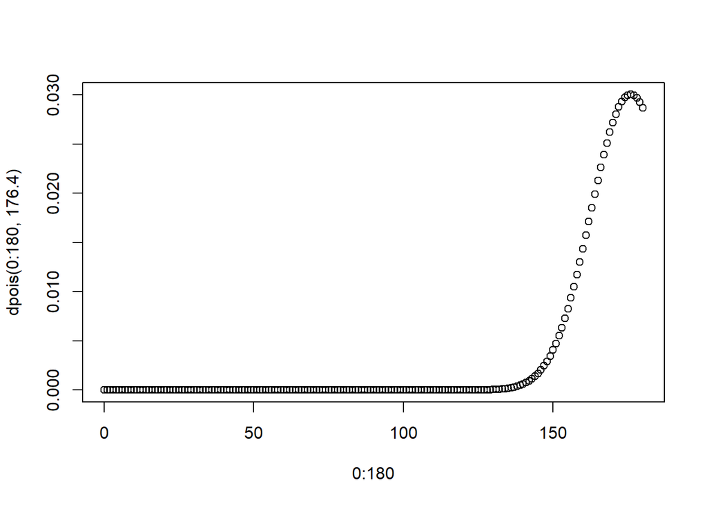

```r
plot(0:180, dpois (0:180, 176.4))
```

```r
porcentaje <-1 - sum(dpois (0:180, 176.4))
porcentaje
```

```
## [1] 0.3744755
```

```r
#Para el caso, porcentaje es igual a 0.3744755
```

## 3. En la planta envasadora de Coca-Cola FEMSA ubicada en Tocancipá se realiza el embotellado de la CocaCola presentación de 400 mL (en promedio), con una desviación estándar de 5 mL (mililitros). Si se sabe por experiencia que este proceso de embotellado sigue una distribución normal, y también se sabe que todo producto con más de 415 mL es declarado como NO CONFORME. Determine el porcentaje de las botellas de gaseosa que son declaradas producto NO CONFORME.

```r
# 400ml = Media
# 5ml = Desviación estandar

# Distribución Normal

# 415ml = No conforme
# X = Númeo de botellas no conformes
# P(X > 415) = 1 - P(X <= 415)
probNoConforme <- 1 - pnorm(415, mean = 400, sd = 5);
porcentajeNoConforme<-probNoConforme*100;
porcentajeNoConforme
```

```
## [1] 0.1349898
```

Por lo tanto, el porcentaje de las botellas de Coca-Cola FEMSA son declaradas producto NO CONFORME es de un 0.13% de probabibilidad.